# Weight Lifting Prediction Analysis

Sérgio Henrique Barra

September 14, 2017

## 1) Summary

This assignment is a course project from Practical Machine Learning course from Coursera and Johns Hopkins University. The dataset is a Weight Lifting Exercise (more info [here](http://web.archive.org/web/20161224072740/http:/groupware.les.inf.puc-rio.br/har)), from Velloso, E., Bulling, A., Gellersen, H., Ugulino, W. and Fuks, H.

The dataset consists in data of 1.25kg-weight lifting of six male participants aged between 20 and 28 years, evaluating how well a participant performed an Unilateral Dumbbell Biceps Curl. The exercise was repeated 10 times, in five different styles of execution:

- Exactly according to the specification (Class A),
- Throwing the elbows to the front (Class B),
- Lifting the dumbbell only halfway (Class C),
- Lowering the dumbbell only halfway (Class D),
- Throwing the hips to the front (Class E).

## 2) Loading data

Loading the necessary packages for the analysis:

```r
library(caret)
library(parallel) # For parallel processing
library(doParallel)
library(randomForest)
library(pander)
```

Downloading, if needed, and reading the training and testing datasets.

```r
if (!(file.exists("pml-training.csv") & file.exists("pml-testing.csv"))) {
trainUrl <- "https://d396qusza40orc.cloudfront.net/predmachlearn/pml-training.csv"
testUrl <- "https://d396qusza40orc.cloudfront.net/predmachlearn/pml-testing.csv"

download.file(trainUrl, "./pml-training.csv")
download.file(testUrl, "./pml-testing.csv")
}

raw_training <- read.csv("./pml-training.csv", stringsAsFactors = FALSE)
testing <- read.csv("./pml-testing.csv", stringsAsFactors = FALSE)
```

## 3) Cleaning Data

The raw training data has **19622** observations of **160** variables.

However, some variables have almost all NA or NULL values. Let’s check which ones are those:

```r
NAsum <- sapply(raw_training, function(x) sum(is.na(x)))
NULLsum <- sapply(raw_training, function(x) sum(x == "", na.rm = TRUE))

tbNA <- table(NAsum)
tbNULL <- table(NULLsum)

df <- data.frame(tbNA, tbNULL)
names(df) <- c("NA in a column", "Frequency", "NULL in a column", "Frequency")
pander(df)
```

| NA in a column | Frequency | NULL in a column | Frequency |
| --- | --- | --- | --- |
| 0 | 93 | 0 | 127 |
| 19216 | 67 | 19216 | 33 |

As we can see, there are **67** columns with **19216** missing values. This represents **97.9%** of NA values in a column, therefore being low valuable for building a machine learning model. Similarly, this also happens with the NULL values. We can now remove these columns from the raw training dataset.

```r
NA_NULLind <- which(NAsum > 0|NULLsum > 0)

training <- raw_training[, -NA_NULLind]
```

For the model, we will consider that the first 7 variables (X, user_name, raw_timestamp_part_1, raw_timestamp_part_2, cvtd_timestamp, new_window, num_window) are not relevant. $X$ is unique and the other 6 variables are only for reference purposes.

```r
training <- training[, 8:60]

print(names(training))
```

```
##  [1] "roll_belt"            "pitch_belt"           "yaw_belt"
##  [4] "total_accel_belt"     "gyros_belt_x"         "gyros_belt_y"
##  [7] "gyros_belt_z"         "accel_belt_x"         "accel_belt_y"
## [10] "accel_belt_z"         "magnet_belt_x"        "magnet_belt_y"
## [13] "magnet_belt_z"        "roll_arm"             "pitch_arm"
## [16] "yaw_arm"              "total_accel_arm"      "gyros_arm_x"
## [19] "gyros_arm_y"          "gyros_arm_z"          "accel_arm_x"
## [22] "accel_arm_y"          "accel_arm_z"          "magnet_arm_x"
## [25] "magnet_arm_y"         "magnet_arm_z"         "roll_dumbbell"
## [28] "pitch_dumbbell"       "yaw_dumbbell"         "total_accel_dumbbell"
## [31] "gyros_dumbbell_x"     "gyros_dumbbell_y"     "gyros_dumbbell_z"
## [34] "accel_dumbbell_x"     "accel_dumbbell_y"     "accel_dumbbell_z"
## [37] "magnet_dumbbell_x"    "magnet_dumbbell_y"    "magnet_dumbbell_z"
## [40] "roll_forearm"         "pitch_forearm"        "yaw_forearm"
## [43] "total_accel_forearm"  "gyros_forearm_x"      "gyros_forearm_y"
## [46] "gyros_forearm_z"      "accel_forearm_x"      "accel_forearm_y"
## [49] "accel_forearm_z"      "magnet_forearm_x"     "magnet_forearm_y"
## [52] "magnet_forearm_z"     "classe"
```

Then, we need to format the integer columns into numeric and the $classe$ column into factor.

```r
INTind <- sapply(training, function(x) class(x) == "integer")
training[, INTind] <- sapply(training[, INTind], as.numeric)
training[, 53] <- as.factor(training[, 53])
```

## 4) Machine Learning Model

Now, the Random Forest model is trained using parallel processing, with a 5 k-fold cross-validation.

```r
cluster <- makeCluster(detectCores() - 1)
registerDoParallel(cluster)

start.time <- Sys.time()

set.seed(1)
ctrl <- trainControl(method = "cv", number = 5, allowParallel = TRUE)
mod_rf <- train(classe ~ ., data = training, trControl = ctrl, method = "rf")

elapsed_rf <- Sys.time() - start.time

stopCluster(cluster)
registerDoSEQ() # R returns to single-threaded processing

print(elapsed_rf)
```

```
## Time difference of 10.53033 mins
```

## 5) Model evaluation

```r
mod_rf$finalModel
```

```
##
## Call:
##  randomForest(x = x, y = y, mtry = param$mtry)
##                Type of random forest: classification
##                      Number of trees: 500
## No. of variables tried at each split: 2
##
##         OOB estimate of  error rate: 0.44%
## Confusion matrix:
##      A    B    C    D    E  class.error
## A 5578    2    0    0    0 0.0003584229
## B   13 3780    4    0    0 0.0044772189
## C    0   17 3403    2    0 0.0055523086
## D    0    0   39 3174    3 0.0130597015
## E    0    0    0    6 3601 0.0016634322
```

Our RF model achieved a relatively **small Out-of-bag error rate** (< 1%), which is a positive factor for model quality. The model has the highest classification error on the D classe, around 1%.

We can see below the importance of the first 15 variables considered by RF model:

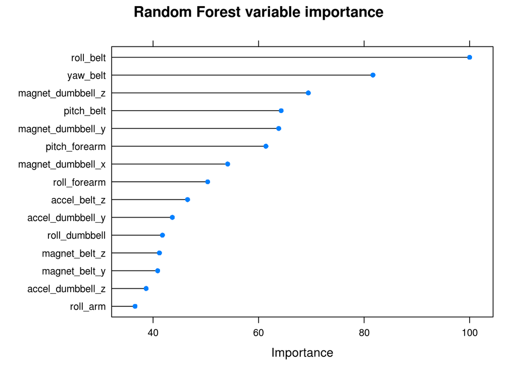

```r
plot(varImp(mod_rf), top = 15, main = "Random Forest variable importance")
```

We can see that **roll_belt** and **yaw_belt** are the two most important variables in the model, showing that the movements on the belt tend to be very relevant to differentiate the quality of the exercise.

## 6) Predicting testing classe variable

Now, using the built model to predict $classe$ in testing dataset:

```r
pred <- predict(mod_rf, testing)
print(pred)
```

```
##  [1] B A B A A E D B A A B C B A E E A B B B
## Levels: A B C D E
```